# DATA505 - Midterm

Characterizing Automobiles

Author

Kaiona Apio

Published

March 17, 2025

# Setup

- Setup

```r
sh <- suppressPackageStartupMessages
sh(library(tidyverse))
sh(library(caret))
sh(library(fastDummies))
sh(library(class))
sh(library(ISLR)) # for the "Auto" dataframe
sh(library(moderndive))
sh(library(dslabs))
sh(library(tidytext))
sh(library(pROC))
```

# Dataframe

- We use the `Auto` dataframe.

```r
head(Auto)
```

```
  mpg cylinders displacement horsepower weight acceleration year origin
1  18         8          307        130   3504         12.0   70      1
2  15         8          350        165   3693         11.5   70      1
3  18         8          318        150   3436         11.0   70      1
4  16         8          304        150   3433         12.0   70      1
5  17         8          302        140   3449         10.5   70      1
6  15         8          429        198   4341         10.0   70      1
                       name
1 chevrolet chevelle malibu
2         buick skylark 320
3        plymouth satellite
4             amc rebel sst
5               ford torino
6          ford galaxie 500
```

- It has the following variable names, which describe various attributes of automobiles.

```r
names(Auto)
```

```
[1] "mpg"          "cylinders"    "displacement" "horsepower"   "weight"
[6] "acceleration" "year"         "origin"       "name"
```

# Multiple Regression

- Run a linear regression model with `mpg` as the dependent variable and `horsepower` and `year` as features (variables).
- Compute and comment on the RMSE.

```r
m1 = lm(mpg ~ horsepower + year, data = Auto)
get_regression_table(m1)
```

```
# A tibble: 3 × 7
  term       estimate std_error statistic p_value lower_ci upper_ci
  <chr>         <dbl>     <dbl>     <dbl>   <dbl>    <dbl>    <dbl>
1 intercept   -12.7       5.35      -2.38   0.018  -23.3     -2.22
2 horsepower   -0.132     0.006    -20.8    0       -0.144   -0.119
3 year          0.657     0.066      9.92   0        0.527    0.788
```

```r
get_regression_points(m1) %>%
    drop_na(residual) %>%
    mutate(sq_residuals = residual^2) %>%
    summarize(rmse = sqrt(mean(sq_residuals))) %>%
    pluck("rmse")
```

```
[1] 4.371492
```

> **Explanation:**

> The RMSE for this problem shows an average deviation of 4.3 by the predicted values when comparing them to the actual data points.

# Feature Engineering

- Create 10 features based on the `name` column.
- Remove all rows with a missing value.
- Ensure only `mpg` and the engineered features remain.
- Compute and comment on the RMSE.

```r
ftAuto = Auto %>%
  mutate(
    chevy = str_detect(name,"chevrolet"),
    honda = str_detect(name,"honda"),
    toyota = str_detect(name,"toyota"),
    dodge = str_detect(name,"dodge"),
    ford = str_detect(name,"ford"),
    nissan = str_detect(name,"nissan"),
    datsun = str_detect(name,"datsun"),
    volvo = str_detect(name,"volvo"),
    fiat = str_detect(name,"fiat"),
    mazda = str_detect(name, "mazda")
  )%>%
  select(chevy, honda, toyota, dodge, ford, nissan, datsun, volvo, fiat, mazda, mpg)%>%
  drop_na()

head(ftAuto)
```

```
  chevy honda toyota dodge  ford nissan datsun volvo  fiat mazda mpg
1  TRUE FALSE  FALSE FALSE FALSE  FALSE  FALSE FALSE FALSE FALSE  18
2 FALSE FALSE  FALSE FALSE FALSE  FALSE  FALSE FALSE FALSE FALSE  15
3 FALSE FALSE  FALSE FALSE FALSE  FALSE  FALSE FALSE FALSE FALSE  18
4 FALSE FALSE  FALSE FALSE FALSE  FALSE  FALSE FALSE FALSE FALSE  16
5 FALSE FALSE  FALSE FALSE  TRUE  FALSE  FALSE FALSE FALSE FALSE  17
6 FALSE FALSE  FALSE FALSE  TRUE  FALSE  FALSE FALSE FALSE FALSE  15
```

```r
m2=lm(mpg~chevy+honda+toyota+dodge+ford+nissan+datsun+volvo+fiat+mazda, data=ftAuto)
get_regression_table(m2)
```

```
# A tibble: 11 × 7
   term       estimate std_error statistic p_value lower_ci upper_ci
   <chr>         <dbl>     <dbl>     <dbl>   <dbl>    <dbl>    <dbl>
 1 intercept    22.4       0.504    44.5     0       21.4     23.4
 2 chevyTRUE    -1.94      1.17     -1.67    0.096   -4.24     0.35
 3 hondaTRUE    11.3       1.98      5.74    0        7.46    15.2
 4 toyotaTRUE    5.96      1.47      4.06    0        3.07     8.84
 5 dodgeTRUE    -0.354     1.40     -0.254   0.8     -3.10     2.39
 6 fordTRUE     -2.94      1.12     -2.64    0.009   -5.13    -0.747
 7 nissanTRUE   13.6       6.91      1.96    0.05    -0.006   27.2
 8 datsunTRUE    8.70      1.52      5.71    0        5.70    11.7
 9 volvoTRUE    -1.30      2.86     -0.454   0.65    -6.92     4.32
10 fiatTRUE      6.50      2.49      2.61    0.009    1.60    11.4
11 mazdaTRUE     8.44      2.24      3.77    0        4.04    12.8
```

```r
get_regression_points(m2) %>%
    drop_na(residual) %>%
    mutate(sq_residuals = residual^2) %>%
    summarize(rmse = sqrt(mean(sq_residuals))) %>%
    pluck("rmse")
```

```
[1] 6.796681
```

> **Explanation:**

> I made it worse. There is a larger RMSE and therefore about a 2 mpg greater deviation in this model’s predictions. I had a feeling that this would happen because gas mileage is fairly dependent on the weight and number of cylinders of a car which were both eliminated in feature engineering. I also generated 10 feature related to the make of each vehicle, but there can be many types of vehicles with varying mpg within each maker.

# Classification

- Use either of $K$-NN or Naive Bayes to predict whether an automobile is a `chevrolet` or a `honda`.
- Explain your choice of technique.
- Report on your Kappa value.

```r
chAuto=Auto%>%
  mutate(
    make = as.factor(ifelse(str_detect(Auto$name, "chevrolet"), "chevrolet", ifelse(str_detect(Auto$name, "honda"), "honda",
                        NA))))
nachAuto=chAuto%>%
  drop_na()

#split
set.seed(505)
coll_index <- createDataPartition(nachAuto$make, p = 0.8, list = FALSE)
atrain <- nachAuto[ coll_index, ]
atest <- nachAuto[-coll_index, ]

#fit
fit <- train(make ~ .,
             data = atrain,
             method = "knn",
             tuneLength = 15,
             metric = "Kappa",
             trControl = trainControl(number = 5, method = "cv"))

#confusion matrix
print(confusionMatrix(predict(fit, atest),factor(atest$make)))
```

```
Confusion Matrix and Statistics

           Reference
Prediction  chevrolet honda
  chevrolet         8     1
  honda             0     1

               Accuracy : 0.9
                 95% CI : (0.555, 0.9975)
    No Information Rate : 0.8
    P-Value [Acc > NIR] : 0.3758

                  Kappa : 0.6154

 Mcnemar's Test P-Value : 1.0000

            Sensitivity : 1.0000
            Specificity : 0.5000
         Pos Pred Value : 0.8889
         Neg Pred Value : 1.0000
             Prevalence : 0.8000
         Detection Rate : 0.8000
   Detection Prevalence : 0.9000
      Balanced Accuracy : 0.7500

       'Positive' Class : chevrolet
```

# Binary Classification

- Predict whether a car is a `honda`.
- Use model weights.
- Display and comment on an ROC curve.

```r
chAuto2=Auto%>%
  mutate(
    make = as.factor(ifelse(str_detect(Auto$name, "chevrolet"), "chevrolet", ifelse(str_detect(Auto$name, "honda"), "honda",
                        "other"))))

set.seed(505)
honda_index <- createDataPartition(chAuto2$make, p = 0.8, list = FALSE)
htrain <- chAuto2[ honda_index, ]
htest <- chAuto2[-honda_index, ]

weight_train = htrain %>%
  mutate(weights = ifelse(make == "honda", 1, 0))

hfit <- train(make ~ .,
             data = htrain,
             method = "knn",
             tuneLength = 15,
             metric = "Kappa",
             trControl = trainControl(number = 5, method = "cv"))

prob <- predict(hfit, newdata = htest, type = "prob")[,2]
hRoc <- roc(htest$make, prob)
hRoc
```

```
Call:
roc.default(response = htest$make, predictor = prob)

Data: prob in 8 controls (htest$make chevrolet) < 2 cases (htest$make honda).
Area under the curve: 0.9375
```

```r
AUC <-auc(hRoc)
```

> **Explanation:**

> The ROC Curve for this problem, shown below, has an Area Under the Curve of about 0.94, which suggests that the model will correctly predict the make as Honda fairly well.

# Ethics

- Based on your analysis, comment on the [Clean Air Act of 1970 and Ammendments of 1977](https://www.epa.gov/clean-air-act-overview/evolution-clean-air-act)
- Discuss the civic reponsibilities of data scientists for:
  - Big Data and Human-Centered Computing
  - Democratic Institutions
  - Climate Change
- Provide at least one statistical measure for each, such as a RMSE, Kappa value, or ROC curve.

##Big Data and Human-Centered Computing

```r
get_regression_points(m1) %>%
    drop_na(residual) %>%
    mutate(sq_residuals = residual^2) %>%
    summarize(rmse = sqrt(mean(sq_residuals))) %>%
    pluck("rmse")
```

```
[1] 4.371492
```

> The RMSE in the code above shows the potential for the model to deviate 4.3 mpg from the actual data. If this model were used by an analyst in the vehicle industry, there is potential to generate an inaccurate mpg mean, which could affect CO2 emission compliance or generate unreliable marketing information that mislead consumers. In relation to human-centered computing, as displayed by my feature engineering, more code does not always result more accurate results. Since there will always be potential for human error, models should be analyzed by teams or at least proofread.

##Democratic Institutions

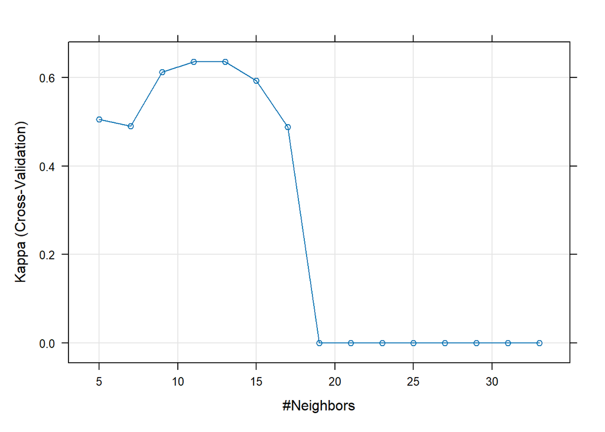

```r
plot(fit, metric="Kappa")
```

> The Kappa value from the first classification problem is around 0.62 and shows some accuracy, but the plot above shows the value dropping as the number of nearest neighbors are included. This is simply because our dataset is smaller, and therefore unfit to advise a democratic institution’s decision making. Large scale decisions and policies should be cautioned with an abundance of data, which this example lacks.

##Climate Change

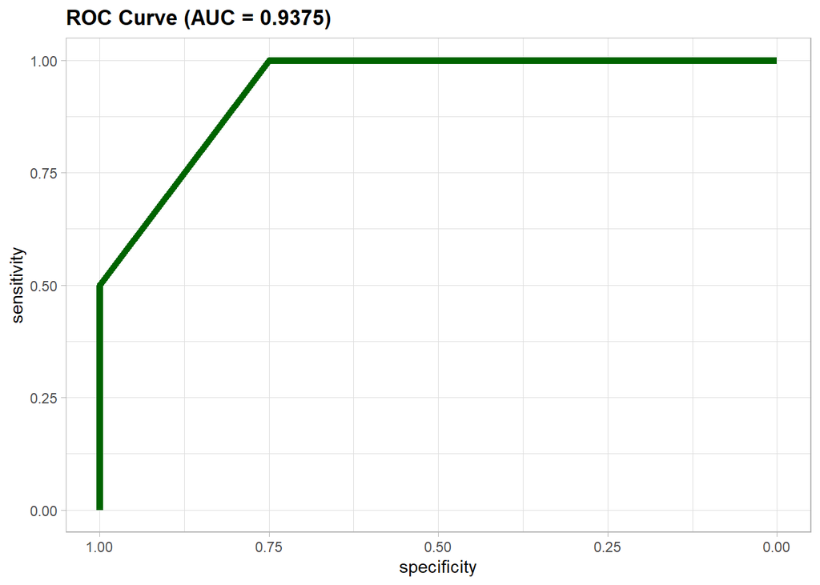

```r
ggroc(hRoc, colour = 'darkgreen', size = 2) +
  ggtitle(paste0('ROC Curve ', '(AUC = ', AUC, ')'))+
  theme_light()+
  theme(plot.title = element_text(face = "bold"))
```

> When assessing data relating to climate change, it is crucial (in my opinion) to be as accurate as possible. My ROC was the most accurate method for today and so that is what I would suggest to a climate data analyst. Accurate models are needed since climate crisis is already devastating for many communities, and it will only worsen. In addition, there are many people who deny climate change and therefore the statistical analyses and models generated need to be as good as they can be.